# Genomic location of HNRNPH binding sites

Mario Keller

Faculty of Biological Sciences, Goethe University Frankfurt

12 December 2022

```r
library(tidyverse)
library(knitr)
library(ggpubr)
library(ggsci)
library(ggvenn)
library(GenomicRanges)
library(rtracklayer)
library(GenomicFeatures)
library(ggrepel)
library(forcats)
```

```r
myTheme <- theme_bw() +
    theme(axis.text = element_text(size = 14, colour="black"),
          axis.title = element_text(size=16, colour="black"),
          axis.ticks=element_line(color="black"),
          axis.ticks.length=unit(.15, "cm"),
          panel.border=element_rect(color="black", fill = NA),
          panel.background = element_blank(),
          plot.background = element_blank(),
          legend.text = element_text(size=12),
          legend.position = "none")
```

```r
projectDir <- "/Users/mariokeller/projects/HNRNPH_project/Tretow_et_al_2023"

iClipDir <- paste0(projectDir, "/4_iCLIP_analysis")
majiqDir <- paste0(projectDir,"/2_MAJIQ_AS_analysis")
dataDir <- paste0(projectDir, "/data")
```

# 1 Background

Once the HNRNPH binding sites were defined, it was of interest to characterize them in more detail. This includes their overlap with genes of different biotypes, features of protein-coding genes and genes with regulated AS events.

# 2 Data

HNRNPH binding sites are loaded from a RDS-File created with *Binding_site_definition.R*.

TPM values of control samples are loaded from a RDS-File created with *Calculate_TPMs_in_Controls.R*.

Annotation is loaded from a zipped GTF-File.

Regulated AS events are loaded from a RDS-File created with *MAJIQ_AS_analysis.Rmd*.

Regulated and non-regulated CE minigenes are loaded from RDS-Files created with *Create_CE_minigenes.R*.

```r
bindingSites <- readRDS(paste0(iClipDir,
                               "/rds_files/HNRNPH_binding_sites.rds"))

controlTPMs <- readRDS(paste0(iClipDir,
                               "/rds_files/controlTPMs.rds"))

anno <- import(paste0(dataDir, "/gencode.v39.annotation.gtf.gz"))

regulatedEvents <- readRDS(paste0(majiqDir, "/rds_files/regulatedEvents.rds"))

regulatedMiniGenes <- readRDS(paste0(iClipDir, "/rds_files/regulatedMiniGenes.rds"))
nonRegulatedMiniGenes <- readRDS(paste0(iClipDir, "/rds_files/nonregulatedMiniGenes.rds"))
```

The annotation is filtered for genes with a support level $\le$ 2 and transcripts with support level $\le$ 3 or NA.

```r
#Filter by gene support level
anno$level <- as.numeric(anno$level)
anno <- anno[anno$level <= 2]

#Filter by transcript support level
anno$transcript_support_level[is.na(anno$transcript_support_level)] <- 0
anno$transcript_support_level[anno$transcript_support_level == "NA"] <- Inf
anno$transcript_support_level <- as.numeric(anno$transcript_support_level)
anno <- anno[anno$transcript_support_level <= 3]

#Filter out transcripts without genes and genes without transcripts
tmpGenes <- anno[anno$type =="gene"]
tmpTranscripts <- anno[anno$type =="transcript"]

geneBlackList <- tmpTranscripts[!tmpTranscripts$gene_id %in% tmpGenes$gene_id]$gene_id %>% unique
geneBlackList <- c(geneBlackList, tmpGenes[!tmpGenes$gene_id %in% tmpTranscripts$gene_id]$gene_id %>% unique)

anno <- anno[!anno$gene_id %in% geneBlackList]

# Create TxDb from annotation
annoTxDb = makeTxDbFromGRanges(anno)

rm(tmpGenes, tmpTranscripts, geneBlackList)
```

The regulated and non-regulated CE events are stored as GRanges objects with 3 ranges (one for each involved exon). For simplicity evens are reduced to the a single range starting at the start of the leftmost exon and ending at the end of the rightmost exon.

```r
regulatedMiniGenes <- lapply(regulatedMiniGenes, function(gr){
  event_id <- gr$event_id %>% unique
  hillCat <- gr$hillCat %>% unique
  # range() reduces the three ranges into one range
  gr <- range(gr)
  gr$event_id <- event_id
  gr$hillCat <- hillCat
  return(gr)
}) %>% as(., "GRangesList") %>% unlist


nonRegulatedMiniGenes <- lapply(nonRegulatedMiniGenes, function(gr){
  event_id <- gr$event_id %>% unique
  # range() reduces the three ranges into one range
  gr <- range(gr)
  gr$event_id <- event_id
  gr$hillCat <- "nonReg"
  return(gr)
}) %>% as(., "GRangesList") %>% unlist

# Combine the minigenes into a single GRanges object
miniGenes <- c(regulatedMiniGenes, nonRegulatedMiniGenes)

rm(regulatedMiniGenes, nonRegulatedMiniGenes)
```

# 3 Genomic distribution of HNRNPH binding sites

In total there are 468,452 called HNRNPH binding sites.

## 3.1 Overlaps with genes

To check the fraction of binding sites overlapping different classes of genes, all genes surviving the mentioned filtering are extracted via genes() from the TxDb object. In addition, the gene_type is changed to “other” if it is not protein_coding or lncRNA.

```r
# Extract genes. Note that this leads to a different resuls than
#   anno[anno$type == 'gene]. Due to the filtering above, there are cases where
#   none of the remaining transcripts reaches the gene start or end. genes()
#   truncates the gene boundaries to the leftmost and rightmost transcript start
#   and end position.
genes = genes(annoTxDb)

# This step adds meta information to the genes
idx = match(genes$gene_id, anno$gene_id)
elementMetadata(genes) = cbind(elementMetadata(genes), elementMetadata(anno)[idx,])

# Adjust the gene_type
genes$gene_type <- ifelse(genes$gene_type %in%  c("protein_coding", "lncRNA"),
                          genes$gene_type,
                          "other")

# Remove the version
genes$gene_id <- genes$gene_id %>%
    strsplit(., ".", fixed=T) %>%
    sapply(., "[[", 1)
```

As a first step, a biotype was assigned to each binding sites based on the overlapping genes. In the case of two or more overlapping genes with different biotypes the following hierarchy was used: protein_coding > lncRNA > other.

```r
#Find overlaps
geneOverlaps <- findOverlaps(bindingSites, genes)

# Turn the Hits object into a data.frame, adjust the column names and add
#   the biotype information
geneOverlaps <- geneOverlaps %>%
    as.data.frame %>%
    dplyr::rename(bindingSites = queryHits, genes = subjectHits)
geneOverlaps$biotype <- genes$gene_type[geneOverlaps$genes]


# Group overlaps by binding site and assign based on the overlapping genes
#   exactly one biotype to each binding site
biotypeOverview <- geneOverlaps %>%
    group_by(bindingSites) %>%
    summarize(bindingSites = bindingSites[1],
              biotype=case_when("protein_coding" %in% biotype  ~ "protein_coding",
                                "lncRNA" %in% biotype ~ "lncRNA",
                                TRUE ~ "other"))

# Initialize the biotype information.
bindingSites$biotype <- "no overlap"

# Add the biotype determined above to the binding site
bindingSites$biotype[biotypeOverview$bindingSites] <- biotypeOverview$biotype
```

Based on the assigned biotypes a pie chart is prepared.

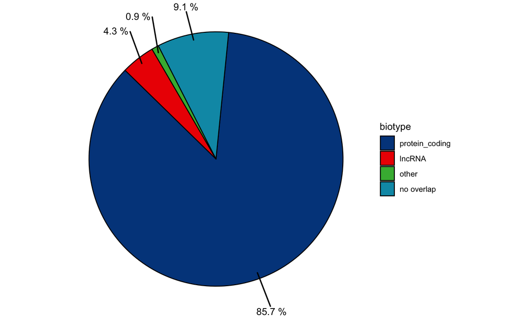

```r
# Create the underlying data.frame
pieDf <- data.frame(biotype=factor(c("protein_coding", "lncRNA",
                                     "other", "no overlap"),
                                   levels=c("protein_coding", "lncRNA",
                                            "other", "no overlap")),
           Freq=c(sum(bindingSites$biotype == "protein_coding"),
                  sum(bindingSites$biotype == "lncRNA"),
                  sum(bindingSites$biotype == "other"),
                  sum(bindingSites$biotype == "no overlap"))) %>%
  mutate(perc=round((Freq/sum(Freq)*100),1)) %>%
  mutate(lab.ypos=(cumsum(c(0, perc)) + c(perc / 2, .01))[1:length(perc)])

# A pie chart is created showing the fraction of binding sites overlapping a
#   certain biotype.
ggplot(pieDf, aes(x="", y=perc, fill = biotype)) +
  scale_fill_lancet() +
  geom_col(color = 'black', position = position_stack(reverse = TRUE),
           show.legend = TRUE) +
  geom_text_repel(aes(x = 1.4, y = lab.ypos, label = paste(perc, "%")),
                  nudge_x = .3, segment.size = .7, show.legend = F) +
  coord_polar('y', start = 0.1) +
  theme_void()
```

Here is the underlying data.frame as a table:

```r
pieDf %>%
    kable(., "html") %>%
    kableExtra::kable_styling("striped") %>%
    kableExtra::scroll_box(height="300px", width = "94%")
```

| biotype | Freq | perc | lab.ypos |
| --- | --- | --- | --- |
| protein_coding | 401495 | 85.7 | 42.85 |
| lncRNA | 20006 | 4.3 | 87.85 |
| other | 4144 | 0.9 | 90.45 |
| no overlap | 42807 | 9.1 | 95.45 |

The vast majority of binding sites overlaps transcripts of protein-coding genes. Around 9% are located in intergenic-regions and could be located on transcripts of yet not annotated genes.

## 3.2 Fraction of bound genes

Of interest is also the fraction of bound genes for each biotype. One problem is that not every gene is expressed, leading to false conclusions when all genes of a biotype are taken into account. To overcome this problem an expression cut-off is applied to only consider expressed genes.

As a first step, the number of expressed genes and the fraction of bound genes is determined in dependence on an increasing expression cut-off. Expression is estimated by the averaged TPM values of the knockdown and overexpression controls.

```r
# Remove the version
controlTPMs$geneID <- controlTPMs$geneID %>%
    strsplit(., ".", fixed=TRUE) %>%
    sapply(., "[[", 1)

# Keep only genes that survived the initial filtering (gene and transcript
#   support level)
controlTPMs <- controlTPMs %>%
    dplyr::filter(geneID %in% genes$gene_id)

# Add the binding information to the genes
genes$bound <- FALSE
genes$bound[findOverlaps(genes, bindingSites) %>% queryHits %>% unique] <- TRUE

# These are all genes that overlap with a binding site (n=11,943)
genesBound <- subsetByOverlaps(genes, bindingSites)

# Cut-off ranges from 0 to 80 with a step size of 1
cutoffs <- seq(0,80,1)

# The number of expressed genes and the fraction of expressed genes bound
#   is determined at each of the 81 cutoffs
boundGenesAtCutoff <- lapply(cutoffs, function(cutoff){
    # Genes expressed at cut-off
    expressedAtCutoff <- controlTPMs %>%
        dplyr::filter(Allmerge >= cutoff) %>%
        pull(geneID)
    # Number of expressed genes bound by HNRNPH
    nBound <- sum((expressedAtCutoff %in% genes[genes$bound]$gene_id))

    return(data.frame(cutoff=cutoff,
                      expressed=length(expressedAtCutoff),
                      fractionBound = nBound/length(expressedAtCutoff)))
}) %>% bind_rows()
```

The results are shown as a combination of a line and bar chart with two y-axes.

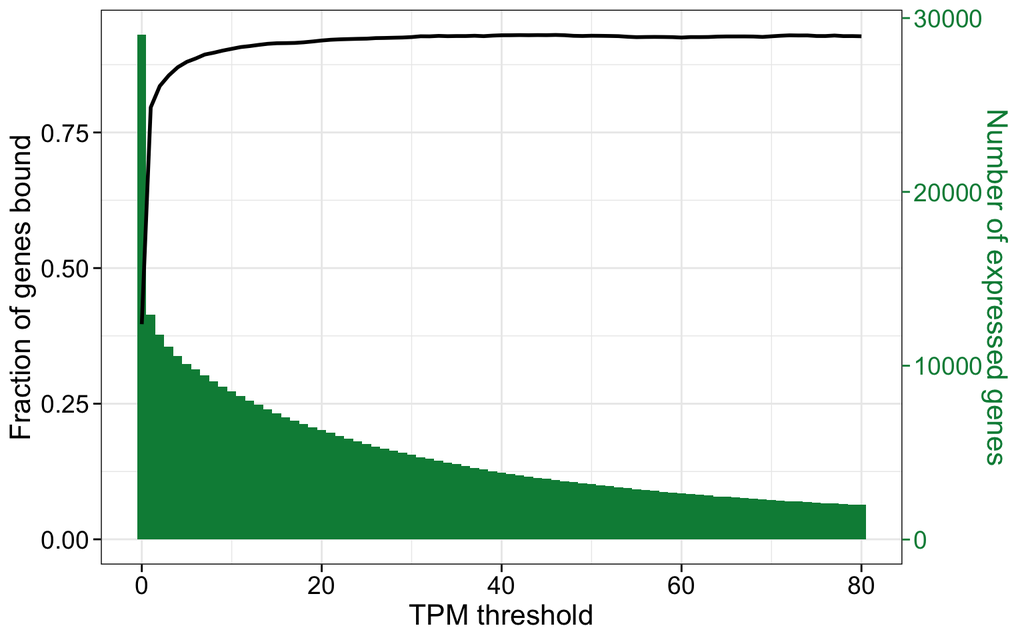

```r
# This coefficient is required for the second y-axis in the plot
coeff <- max(boundGenesAtCutoff$expressed) /
    max(boundGenesAtCutoff$fractionBound)

# The plot is a combination of a line and bar chart using two y-axes.
ggplot() +
  geom_col(data=boundGenesAtCutoff, aes(x=cutoff, y=expressed/coeff),
           fill="springgreen4", width=1) +
  geom_line(data=boundGenesAtCutoff, aes(x=cutoff, y=fractionBound), size=1) +
  scale_x_continuous(breaks=seq(0,80,20)) +
  scale_y_continuous(name = "Fraction of genes bound",
                     limits = c(0,max(boundGenesAtCutoff$fractionBound)),
    sec.axis = sec_axis(trans=~.*coeff, name="Number of expressed genes")) +
  labs(x="TPM threshold", y="") +
  myTheme +
  theme(
    axis.title.y.right = element_text(color = "springgreen4", size=16),
    axis.ticks.y.right = element_line(color="springgreen4"),
    axis.text.y.right =  element_text(size = 14, colour="springgreen4")
  )
```

After observing that the fraction of bound genes is more or less stabilized at a TPM cut-off of 1, genes were considered as expressed if their average TPM value was $\ge$ 1.

```r
genes$expressed <- FALSE

genes$expressed[genes$gene_id %in%
                    controlTPMs$geneID[controlTPMs$Allmerge >= 1]] <- TRUE

genesExpressed <- genes[genes$expressed]
```

Based on the information if genes are expressed and if they are bound, the fraction of expressed genes bound by HNRNPH was determined for each biotype.

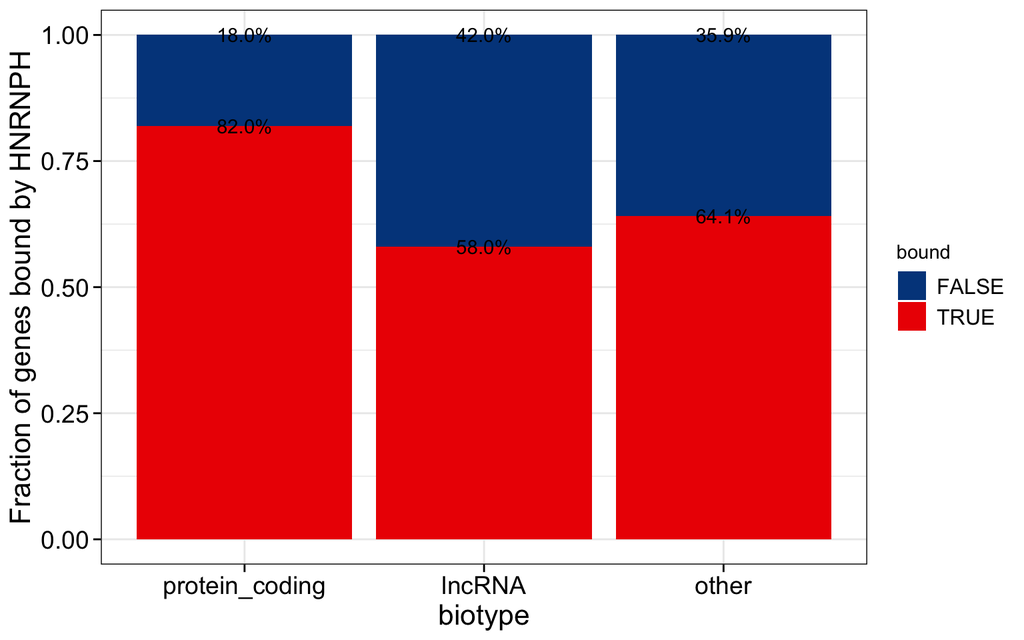

```r
genesExpressedBound <- genes[genes$expressed & genes$bound]

# Determine the fraction of bound genes per biotype
fractionBoundGenes <- data.frame(
    biotype=factor(c("protein_coding", "lncRNA", "other"),
                   levels=c("protein_coding", "lncRNA", "other")),
    bound = c(sum(genesExpressedBound$gene_type == "protein_coding"),
              sum(genesExpressedBound$gene_type == "lncRNA"),
              sum(genesExpressedBound$gene_type == "other")),
    nonBound = c(sum(genesExpressed$gene_type == "protein_coding") -
                     sum(genesExpressedBound$gene_type == "protein_coding"),
                 sum(genesExpressed$gene_type == "lncRNA") -
                     sum(genesExpressedBound$gene_type == "lncRNA"),
                 sum(genesExpressed$gene_type == "other") -
                     sum(genesExpressedBound$gene_type == "other"))) %>%
    pivot_longer(., cols=2:3, values_to="nGenes", names_to = "bound") %>%
    mutate(bound = ifelse(bound == "bound", TRUE, FALSE)) %>%
    mutate(bound=factor(bound, levels=c(FALSE, TRUE))) %>%
    group_by(biotype) %>%
    mutate(fraction = nGenes / sum(nGenes)) %>%
    ungroup

# A stacked barchart is created for each of the three biotypes. Stacks
#   indicate the fraction of genes bound and not bound by HNRNPH. In addition,
#   the percentage of genes bound and not bound is added.
ggplot(fractionBoundGenes, aes(x=biotype, y=nGenes, fill=bound)) +
  scale_fill_lancet() +
  geom_col(position = "fill") +
  geom_text(aes(label = scales::percent(fraction)), position = 'fill') +
  labs(y="Fraction of genes bound by HNRNPH") +
  myTheme +
  theme(legend.position = "right")
```

Here is the underlying data.frame as a table:

```r
fractionBoundGenes %>%
    kable(., "html") %>%
    kableExtra::kable_styling("striped") %>%
    kableExtra::scroll_box(height="300px", width = "94%")
```

| biotype | bound | nGenes | fraction |
| --- | --- | --- | --- |
| protein_coding | TRUE | 9538 | 0.8196271 |
| protein_coding | FALSE | 2099 | 0.1803729 |
| lncRNA | TRUE | 625 | 0.5797774 |
| lncRNA | FALSE | 453 | 0.4202226 |
| other | TRUE | 148 | 0.6406926 |
| other | FALSE | 83 | 0.3593074 |

HNRNPH binds transcripts of around 80% of all expressed protein-coding genes, while the fraction is lower for other biotypes.

## 3.3 Overlaps with features of protein-coding genes

As most binding sites overlap protein-coding genes, it was of interest to check in which features these are located. Using GenomicFeatures functions, CDS, Intron, 5’UTR and 3’UTR regions (features) were extracted.

Next, to each binding site overlapping a protein-coding gene, one of the four features is assigned. In the case of multiple different overlapping features (e.g. 2xCDS and 1xIntron), the more abundant one is assigned (CDS for the example). If there was still a tie (e.g. 2xCDS and 2xIntron), the following hierarchy is used : CDS > UTR5 > UTR3 > Intron. In rare cases there is no overlap at all, which occurs when a gene harbors transcripts in the beginning and end but lacks any transcripts in the middle (could also be due to annotation filtering). These cases are considered as “Outside”.

```r
# Subset binding sites to those overlapping protein_coding genes
bindingSitesPCGs <- subsetByOverlaps(bindingSites,
                                     genes[genes$gene_type == "protein_coding"])

# Count for each binding site the overalp with the four features. In some cases
#   a binding site overlaps no feature, which is defined as "Outside".
CDS = cds(annoTxDb) %>%
    countOverlaps(bindingSitesPCGs,.)
Intron = unlist(intronsByTranscript(annoTxDb)) %>%
    countOverlaps(bindingSitesPCGs,.)
UTR3 = unlist(threeUTRsByTranscript(annoTxDb)) %>%
    countOverlaps(bindingSitesPCGs,.)
UTR5 = unlist(fiveUTRsByTranscript(annoTxDb)) %>%
    countOverlaps(bindingSitesPCGs,.)
overlapCounts <- data.frame(CDS, UTR5, UTR3, Intron)
overlapCounts$Outside <- ifelse(rowSums(overlapCounts)==0, 1, 0)

# A hierarchy is defined for ties
featureHierarchy <- c("CDS", "UTR5", "UTR3", "Intron", "Outside")

# Arrange the columns by the defined hierarchy
overlapCounts <- overlapCounts[featureHierarchy] %>% as.matrix

# Assign to each binding site the feature with the highest number.
names = colnames(overlapCounts)
feature = apply(overlapCounts, 1, function(x){ names[which.max(x)] })

# Add the final feature to the binding site
bindingSitesPCGs$feature = feature
```

Based on the assigned features a pie chart is prepared.

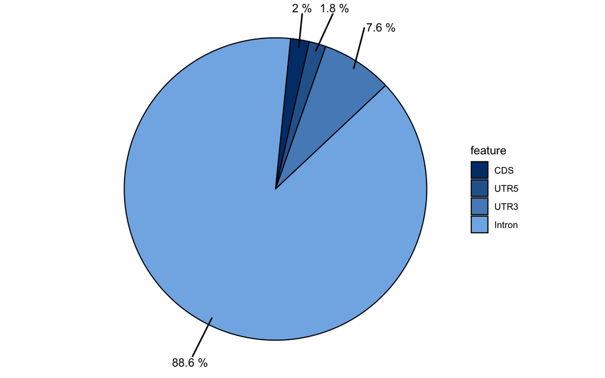

```r
# Create the underlying data.frame. Note that "Outside" is not considered.
pieDf <- data.frame(feature=factor(c("CDS", "UTR5", "UTR3", "Intron"),
                                   levels=c("CDS", "UTR5", "UTR3", "Intron")),
           Freq=c(sum(bindingSitesPCGs$feature == "CDS"),
                  sum(bindingSitesPCGs$feature == "UTR5"),
                  sum(bindingSitesPCGs$feature == "UTR3"),
                  sum(bindingSitesPCGs$feature == "Intron"))) %>%
  mutate(perc=round((Freq/sum(Freq)*100),1)) %>%
  mutate(lab.ypos=(cumsum(c(0, perc)) + c(perc / 2, .01))[1:length(perc)])

# A pie chart is created showing the fraction of binding sites overlapping a
#   certain feature
ggplot(pieDf, aes(x="", y=perc, fill = feature)) +
  scale_fill_manual(values=sapply(4,colorRampPalette(c("#003C77", "#81B4E7")))) +
  geom_col(color = 'black', position = position_stack(reverse = TRUE),
           show.legend = TRUE) +
  geom_text_repel(aes(x = 1.4, y = lab.ypos, label = paste(perc, "%")),
                  nudge_x = .3, segment.size = .7, show.legend = F) +
  coord_polar('y', start = 0.1) +
  theme_void()
```

Here is the underlying data.frame as a table:

```r
pieDf %>%
    kable(., "html") %>%
    kableExtra::kable_styling("striped") %>%
    kableExtra::scroll_box(height="300px", width = "94%")
```

| feature | Freq | perc | lab.ypos |
| --- | --- | --- | --- |
| CDS | 7858 | 2.0 | 1.0 |
| UTR5 | 7280 | 1.8 | 2.9 |
| UTR3 | 30471 | 7.6 | 7.6 |
| Intron | 352746 | 88.6 | 55.7 |

Nearly 90% of the binding sites on protein-coding genes are located in introns and around 8% in the 3’UTR. However, since introns make up most of the length of a gene, this is not very surprising.

# 4 Binding on alternative spliced genes

## 4.1 Overlaps with alternatively spliced genes

Another interesting thing to check is whether genes with regulated AS events are bound by HNRNPH. To answer this quesiton, all genes with at least one regulated AS event are loaded, followed by a filtering for genes defined as expressed. The overlap of genes with regulated AS events and genes bound by HNRNPH was afterwards determined.

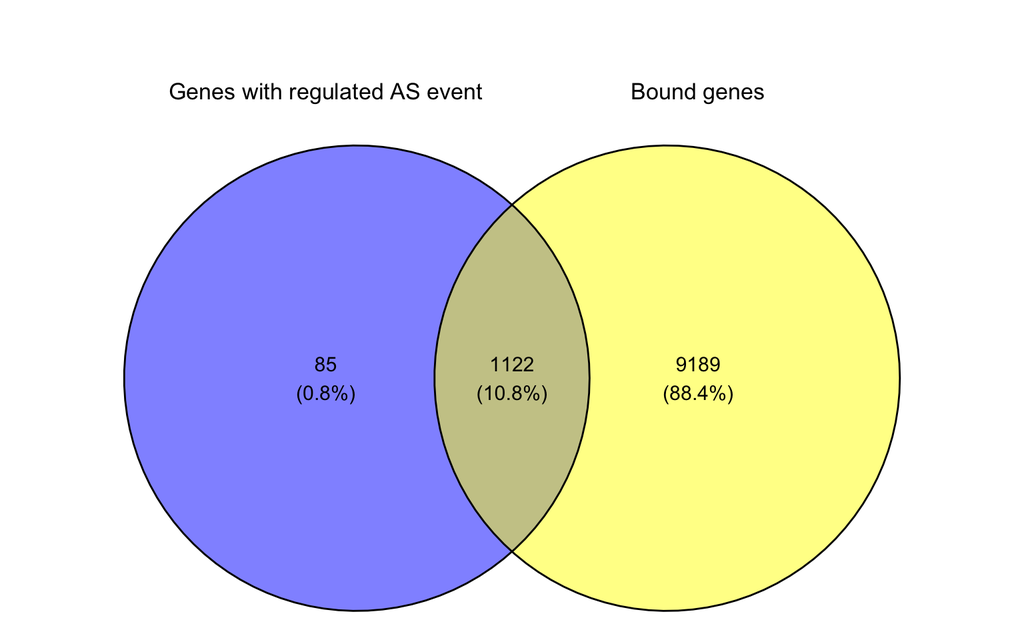

```r
# Extract the gene identifier of all genes with at least one regulated AS event
genesWithRegulatedASevent <- regulatedEvents$module_id %>%
    strsplit(., ".", fixed=T) %>%
    sapply(., "[[", 1) %>% unique

# Filter for genes defined as expressed (TPM >= 1)
genesWithRegulatedASevent <- genesWithRegulatedASevent[
    genesWithRegulatedASevent %in% genes[genes$expressed]$gene_id
    ]

vennList <- list('Genes with regulated AS event' = genesWithRegulatedASevent,
                 'Bound genes' = genes$gene_id[genes$expressed & genes$bound])

ggvenn(data=vennList, text_size=4, set_name_size=4.5, stroke_size=.5) +
  scale_y_continuous(limits = c(-1, 1.5))
```

One can see that more than 90% of the genes with regulated AS events are bound by HNRNH. Yet the question is whether this overlap is significant. To answer this question a Fisher’s exact test was applied.

```r
total <- genes[genes$expressed] %>% length


reg_true__bound_true <- intersect(genesWithRegulatedASevent,
                                  genes$gene_id[genes$expressed &
                                                    genes$bound]) %>% length
reg_true__bound_false <- length(genesWithRegulatedASevent) - reg_true__bound_true
reg_false__bound_true <- length(genes[genes$expressed &
                                          genes$bound]) - reg_true__bound_true
reg_false__bound_false <- total -
    (reg_true__bound_true + reg_true__bound_false +reg_false__bound_true)


contingencyTable <- matrix(c(reg_true__bound_true, reg_true__bound_false,
                             reg_false__bound_true, reg_false__bound_false),
                           dimnames=list(c("bound_true", "bound_false"),
                                         c("reg_true", "reg_false")), nrow=2)
fisherRes <- fisher.test(contingencyTable, alternative = "greater")

contingencyTable
```

```
##             reg_true reg_false
## bound_true      1122      9189
## bound_false       85      2550
```

```r
fisherRes
```

```
##
##  Fisher's Exact Test for Count Data
##
## data:  contingencyTable
## p-value < 2.2e-16
## alternative hypothesis: true odds ratio is greater than 1
## 95 percent confidence interval:
##  3.023951      Inf
## sample estimates:
## odds ratio
##   3.663043
```

We can see that the overlap is significant (P-value: 5.9153674^{-41}.

## 4.2 Overlaps with regulated and non-regulated CE events

Having established that almost all genes with regulated AS events are bound by HNRNPH, we asked for the CE events whether the binding actually occurs in the alternatively spliced region. The alternatively spliced region of CE events (3 exons involved) was defined as the region starting at the leftmost exon and the ending at the rightmost exon.

For the cooperatively enhanced (Coop-Enh), repressed (Coop-Rep) and control (non-regulated) events (nonReg) we determined if they are bound (plot1) and also how many binding sites are located in their region (plot2).

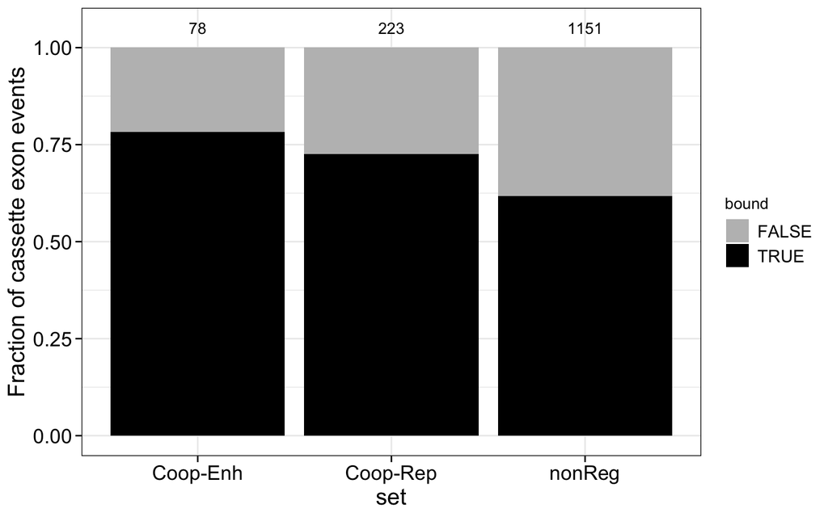

```r
# Store binding information (TRUE/FALSE) and the number of overlapping
#   binding sites
miniGenes$bound <- countOverlaps(miniGenes, bindingSites) > 0
miniGenes$nBSs <- countOverlaps(miniGenes, bindingSites)

# Filter for cooperative enhanced, cooperatively repressed and non-regulated
#   events. Limit more than 5 BSs to ">5".
miniGenes <- miniGenes %>%
    as.data.frame %>%
    dplyr::select(hillCat, bound, nBSs) %>%
    dplyr::filter(hillCat %in% c("Coop-Enh", "Coop-Rep", "nonReg")) %>%
    mutate(hillCat = factor(hillCat, levels=c("Coop-Enh", "Coop-Rep", "nonReg"))) %>%
    mutate(nBSs=ifelse(nBSs > 5, ">5", nBSs)) %>%
    mutate(nBSs = factor(nBSs, levels=c("0", "1", "2", "3", "4", "5", ">5")))

miniGenes %>%
    ggplot(., aes(x=hillCat, fill=bound)) +
        geom_bar(position="fill") +
        geom_text(data=. %>% dplyr::count(hillCat), aes(label = n, x=hillCat, y=1.05), inherit.aes=F) +
        scale_fill_manual(values=c("FALSE" = "grey", "TRUE" = "black")) +
        labs(x="set", y="Fraction of cassette exon events") +
        myTheme +
        theme(legend.position = "right")
```

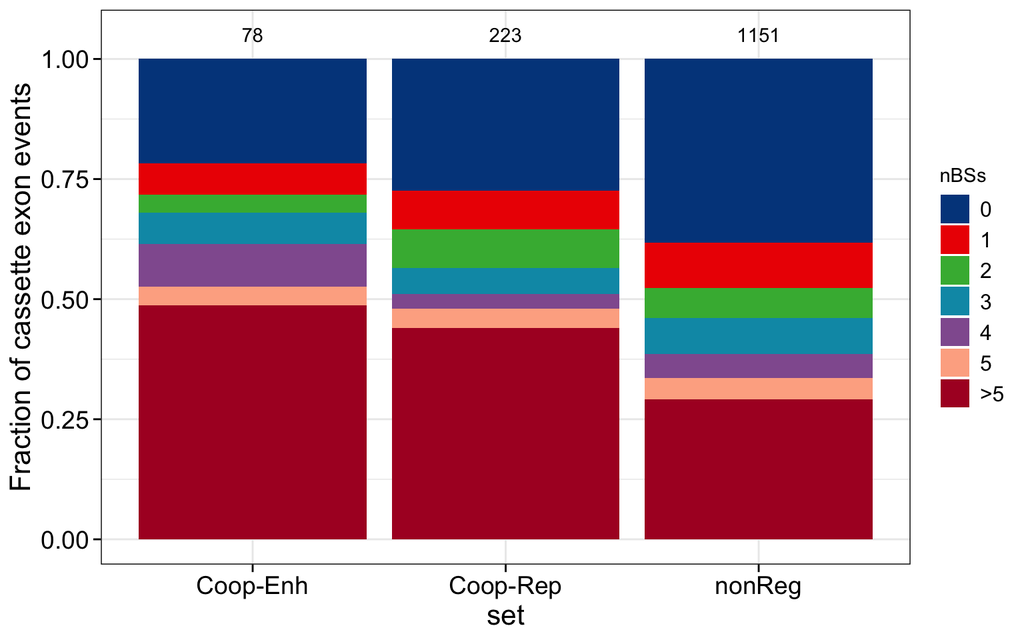

```r
miniGenes %>%
    ggplot(., aes(x=hillCat, fill=nBSs)) +
        geom_bar(position="fill") +
        geom_text(data=. %>% dplyr::count(hillCat), aes(label = n, x=hillCat, y=1.05), inherit.aes=F) +
        scale_fill_lancet() +
        labs(x="set", y="Fraction of cassette exon events") +
        myTheme +
        theme(legend.position = "right")
```

The highest fraction of binding is observed for the cooperatively enhanced CE events, followed by the repressed ones. In addition, for all three sets a lot of the events have more than 5 binding sites. However, what must be taken into account is that the events could have a different length. Also the length of the regulatory region (the cassette exon or flanking introns) could have an impact on the number of binding sites.